# RNA-Seq: quantification and DE analysis

Laura Toribio-Celestino

May 2023

### Loading required packages

```r
library(Rsubread)
library(DESeq2)
library(apeglm)
library(dplyr)
library(ggplot2)
library(pheatmap)
library(RColorBrewer)
library(EnhancedVolcano)
```

# Quantification with featureCounts

Let’s start by reading the sorted BAM files and the annotation SAF file located in this directory.

```r
bamfiles <- dir(".", ".bam$")
saffile <- dir(".", "saf$")
```

Next, gene-level quantification is performed using featureCounts, which is faster than other methods and requires less computer memory. Strandness was checked before running.

```r
fc <- featureCounts(bamfiles, annot.ext=saffile, strandSpecific=2, isPairedEnd=TRUE, nthreads=15)
```

[output not shown]

[output cut: 22 more lines]

```
## ||    Total alignments : 14949127                                             ||
## ||    Successfully assigned alignments : 14140656 (94.6%)                     ||
## ||    Running time : 0.40 minutes                                             ||
## ||                                                                            ||
## || Process BAM file C063p.2.bam...                                            ||
## ||    Strand specific : reversely stranded                                    ||
## ||    Paired-end reads are included.                                          ||
## ||    Total alignments : 14597942                                             ||
## ||    Successfully assigned alignments : 13791462 (94.5%)                     ||
## ||    Running time : 0.41 minutes                                             ||
## ||                                                                            ||
## || Write the final count table.                                               ||
## || Write the read assignment summary.                                         ||
## ||                                                                            ||
## \\============================================================================//
```

Count data is exported to a TSV file. Here we’ll see some stats of the count data.

```r
write.table(x=data.frame(fc$annotation[,c("GeneID","Chr", "Length")], fc$counts, stringsAsFactors=FALSE), file="featureCounts.tsv", quote=FALSE, sep="\t", row.names=FALSE)
head(fc$counts)
```

```
##                    C063.1.bam C063.2.bam C063.3.bam C063p.1.bam C063p.2.bam
## cds-pgaptmp_000001       3454       3396       2980        5380        5254
## cds-pgaptmp_000002       1869       1849       1531        2617        2417
## cds-pgaptmp_000003        794        758        760         991        1145
## cds-pgaptmp_000004       6634       6492       5720        8343        7774
## cds-pgaptmp_000005         16         19          9          23          27
## cds-pgaptmp_000006       1665       1536       1722        2652        2666
```

```r
summary(fc$counts)
```

```
##    C063.1.bam        C063.2.bam        C063.3.bam       C063p.1.bam
##  Min.   :      0   Min.   :      0   Min.   :      0   Min.   :      0
##  1st Qu.:     28   1st Qu.:     26   1st Qu.:     22   1st Qu.:     32
##  Median :    191   Median :    189   Median :    159   Median :    222
##  Mean   :   2642   Mean   :   2644   Mean   :   2375   Mean   :   2795
##  3rd Qu.:   1050   3rd Qu.:   1040   3rd Qu.:    931   3rd Qu.:   1250
##  Max.   :1725609   Max.   :2001410   Max.   :1870999   Max.   :1964588
##   C063p.2.bam
##  Min.   :      0
##  1st Qu.:     31
##  Median :    209
##  Mean   :   2726
##  3rd Qu.:   1169
##  Max.   :2203353
```

```r
fc$stat
```

```
##                           Status C063.1.bam C063.2.bam C063.3.bam C063p.1.bam
## 1                       Assigned   13363808   13377560   12013604    14140656
## 2            Unassigned_Unmapped      13285      11220      10814       11315
## 3           Unassigned_Read_Type          0          0          0           0
## 4           Unassigned_Singleton          0          0          0           0
## 5      Unassigned_MappingQuality          0          0          0           0
## 6             Unassigned_Chimera          0          0          0           0
## 7      Unassigned_FragmentLength          0          0          0           0
## 8           Unassigned_Duplicate          0          0          0           0
## 9        Unassigned_MultiMapping          0          0          0           0
## 10          Unassigned_Secondary          0          0          0           0
## 11           Unassigned_NonSplit          0          0          0           0
## 12         Unassigned_NoFeatures     227828     374968     182285      183043
## 13 Unassigned_Overlapping_Length          0          0          0           0
## 14          Unassigned_Ambiguity     670465     660936     563031      614113
##    C063p.2.bam
## 1     13791462
## 2         6971
## 3            0
## 4            0
## 5            0
## 6            0
## 7            0
## 8            0
## 9            0
## 10           0
## 11           0
## 12      187254
## 13           0
## 14      612255
```

The count matrices are prepared for the construction of the DESeqDataSet object. Gene IDs are set as row names.

```r
countdata <- fc$counts
colnames(countdata) <- gsub("\\.bam$", "", colnames(countdata))
nrow(countdata)
```

```
## [1] 5059
```

Plotting the total read counts of each sample.

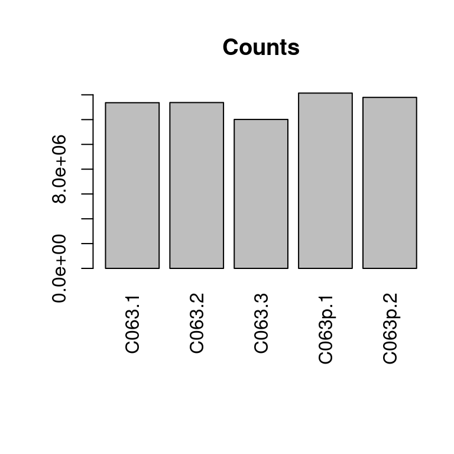

```r
par(mar=c(8,4,4,1)+0.1)
barplot(colSums(countdata), las=3, main="Counts")
```

# DESeqDataSet object and experimental design

Building the variables for the columns of the colData object. The condition of all samples and replicates is specified.

```r
condition <- c('wt', 'wt', 'wt', 'tc', 'tc')
replicate <- c('1', '2', '3', '1', '2')
coldata <- as.data.frame(cbind(colnames(countdata), condition, replicate))
coldata
```

```
##        V1 condition replicate
## 1  C063.1        wt         1
## 2  C063.2        wt         2
## 3  C063.3        wt         3
## 4 C063p.1        tc         1
## 5 C063p.2        tc         2
```

Constructing the DESeqDataSet object.

```r
dds <- DESeqDataSetFromMatrix(countData = countdata, colData = coldata, design = ~ condition)
head(dds)
```

```
## class: DESeqDataSet
## dim: 6 5
## metadata(1): version
## assays(1): counts
## rownames(6): cds-pgaptmp_000001 cds-pgaptmp_000002 ...
##   cds-pgaptmp_000005 cds-pgaptmp_000006
## rowData names(0):
## colnames(5): C063.1 C063.2 C063.3 C063p.1 C063p.2
## colData names(3): V1 condition replicate
```

```r
nrow(dds)
```

```
## [1] 5059
```

The reference level of the condition’s factors must be specified. The reference will be defined as the pOXA-48-free version of the strain.

```r
dds$condition <- relevel(dds$condition, ref = "wt")
```

## Pre-filtering the dataset

```r
keep <- rowSums(counts(dds)) > 1
dds <- dds[keep,]
nrow(dds)
```

```
## [1] 5003
```

# Analysis of count data

Before exploratory analyses, count data is transformed to stabilize the variance across the mean. The rlog transformation is applied since it works best on small datasets (n<30), in comparison with the VST method.

```r
rld <- rlog(dds, blind = FALSE)
head(assay(rld))
```

```
##                       C063.1    C063.2    C063.3   C063p.1   C063p.2
## cds-pgaptmp_000001 11.791422 11.780456 11.767523 12.183423 12.220561
## cds-pgaptmp_000002 10.899943 10.897288 10.807787 11.145930 11.108465
## cds-pgaptmp_000003  9.670956  9.622852  9.781055  9.761110 10.013333
## cds-pgaptmp_000004 12.723108 12.705721 12.698125 12.828376 12.802306
## cds-pgaptmp_000005  4.142176  4.204675  4.022297  4.217186  4.302836
## cds-pgaptmp_000006 10.745404 10.650537 10.961566 11.161942 11.237147
```

### Heatmap of distances between samples

To observe the similarities and dissimilarities between samples, we plot a heatmap of Euclidean distances. Replicates from each condition should cluster together.

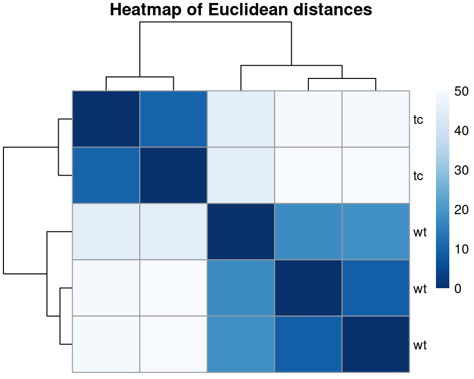

```r
sampleDists <- dist(t(assay(rld)))
sampleDistMatrix <- as.matrix(sampleDists)
rownames(sampleDistMatrix) <- paste(rld$condition, sep="-")
colnames(sampleDistMatrix) <- NULL
colors <- colorRampPalette(rev(brewer.pal(9, "Blues")))(255)
pheatmap(sampleDistMatrix,
         clustering_distance_rows=sampleDists,
         clustering_distance_cols=sampleDists,
         col=colors,
         main="Heatmap of Euclidean distances")
```

### PCA plot

In PCA plots, samples are projected onto the 2D plane such that they spread out in the two directions that explain most of the differences betweem them. The x-axis (PC1) is the direction that separates the data points the most. The y-axis (PC2) is the direction that separates the data the second most. The percent of the total variance that is contained in the direction is printed in the axis label. Replicates from each condition should cluster together.

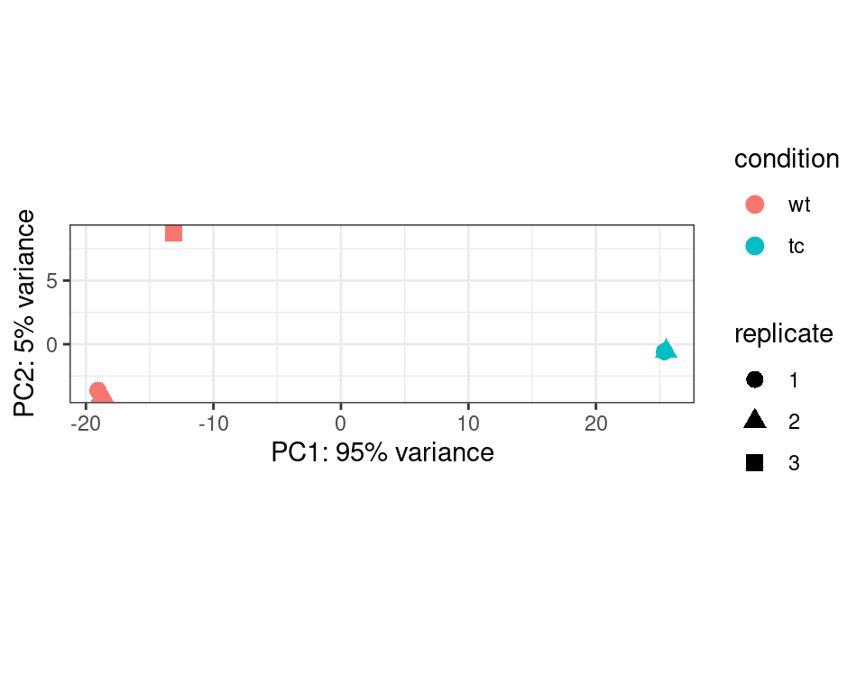

```r
pcaData <- plotPCA(rld, intgroup = c("condition", "replicate"), returnData = TRUE)
percentVar <- round(100 * attr(pcaData, "percentVar"))
ggplot(pcaData, aes(x = PC1, y = PC2, color = condition, shape = replicate)) +
  geom_point(size =3) +
  xlab(paste0("PC1: ", percentVar[1], "% variance")) +
  ylab(paste0("PC2: ", percentVar[2], "% variance")) +
  coord_fixed() +
  theme_bw()
```

## Differential expression analysis

As we have already specified an experimental design when we created the DESeqDataSet, we can run the differential expression pipeline on the raw counts:

```r
dds <- DESeq(dds)
resultsNames(dds)
```

```
## [1] "Intercept"          "condition_tc_vs_wt"
```

We’ll have a look at the summary of the unfiltered DE results. The LFC is shrunken with the apeglm method for visualizing results and ranking the genes for GSEA analysis.

```r
res <- results(dds)
res <- lfcShrink(dds, coef="condition_tc_vs_wt", type="apeglm")
```

```
## using 'apeglm' for LFC shrinkage. If used in published research, please cite:
##     Zhu, A., Ibrahim, J.G., Love, M.I. (2018) Heavy-tailed prior distributions for
##     sequence count data: removing the noise and preserving large differences.
##     Bioinformatics. https://doi.org/10.1093/bioinformatics/bty895
```

```r
res
```

```
## log2 fold change (MAP): condition tc vs wt
## Wald test p-value: condition tc vs wt
## DataFrame with 5003 rows and 5 columns
##                     baseMean log2FoldChange     lfcSE      pvalue        padj
##                    <numeric>      <numeric> <numeric>   <numeric>   <numeric>
## cds-pgaptmp_000001 4000.4261       0.448940 0.0679590 2.84919e-11 2.52356e-10
## cds-pgaptmp_000002 2018.1708       0.275822 0.0818818 6.67178e-04 2.16213e-03
## cds-pgaptmp_000003  877.7612       0.215290 0.1248848 7.76100e-02 1.49143e-01
## cds-pgaptmp_000004 6901.2595       0.112416 0.0631758 7.35498e-02 1.43091e-01
## cds-pgaptmp_000005   18.2431       0.306685 0.4305928 3.22347e-01 4.62374e-01
## ...                      ...            ...       ...         ...         ...
## cds-pgaptmp_005078   22.0211     -1.4554979 0.5809749 1.27450e-03 3.93799e-03
## cds-pgaptmp_005069  487.1556     -0.7375819 0.1380075 3.65102e-08 2.25473e-07
## cds-pgaptmp_005080 1535.1192     -0.7921307 0.1089589 1.29946e-13 1.43733e-12
## cds-pgaptmp_005081  433.3936     -0.6042132 0.1347856 3.86298e-06 1.84048e-05
## cds-pgaptmp_005079 1517.0346     -0.0240102 0.0955788 7.98298e-01 8.66923e-01
```

```r
summary(res)
```

```
##
## out of 5003 with nonzero total read count
## adjusted p-value < 0.1
## LFC > 0 (up)       : 1130, 23%
## LFC < 0 (down)     : 1157, 23%
## outliers [1]       : 0, 0%
## low counts [2]     : 291, 5.8%
## (mean count < 3)
## [1] see 'cooksCutoff' argument of ?results
## [2] see 'independentFiltering' argument of ?results
```

The unfiltered DE results are exported to a TSV file (contains NAs and non-significant DEGs).

```r
## The saf file, which contains the RefSeq IDs is read
saftable <- read.csv(saffile, header=TRUE, sep="\t")
saftable <- as.data.frame(saftable)
## Merge with normalized count data and annotation
resdata <- merge(as.data.frame(res), as.data.frame(counts(dds, normalized=TRUE)), by="row.names", sort=FALSE)
names(resdata)[1] <- "GeneID"
resdata <- merge(x=as.data.frame(resdata), saftable, by="GeneID")
head(resdata)
```

```
##               GeneID   baseMean log2FoldChange      lfcSE       pvalue
## 1 cds-pgaptmp_000001 4000.42609      0.4489400 0.06795899 2.849186e-11
## 2 cds-pgaptmp_000002 2018.17078      0.2758217 0.08188180 6.671777e-04
## 3 cds-pgaptmp_000003  877.76119      0.2152898 0.12488485 7.761000e-02
## 4 cds-pgaptmp_000004 6901.25954      0.1124156 0.06317580 7.354981e-02
## 5 cds-pgaptmp_000005   18.24305      0.3066846 0.43059278 3.223472e-01
## 6 cds-pgaptmp_000006 2008.62710      0.4301022 0.11799235 1.935951e-04
##           padj    C063.1     C063.2     C063.3    C063p.1    C063p.2 Chr Start
## 1 2.523565e-10 3515.5467 3486.88878 3453.18317 4707.30920 4839.20256   1     1
## 2 2.162133e-03 1902.3037 1898.48567 1774.10182 2289.78219 2226.18055   1  1409
## 3 1.491429e-01  808.1483  778.28672  880.67759  867.08985 1054.60353   1  2509
## 4 1.430911e-01 6752.2111 6665.74851 6628.25762 7299.82911 7160.25137   1  3611
## 5 4.623744e-01   16.2851   19.50851   10.42908   20.12418   24.86838   1  6265
## 6 6.979495e-04 1694.6686 1577.10871 1995.43000 2320.40595 2455.52227   1  6778
##    End Strand Type         RefSeq Gene
## 1 1404      +  CDS    NP_418157.1 dnaA
## 2 2509      +  CDS WP_006177590.1 dnaN
## 3 3582      +  CDS WP_005121479.1 recF
## 4 6025      +  CDS WP_005121480.1 gyrB
## 5 6663      +  CDS    NP_312660.2    -
## 6 7590      +  CDS    NP_418152.1 yidA
##                                          Product
## 1 chromosomal replication initiator protein DnaA
## 2                DNA polymerase III subunit beta
## 3            DNA replication/repair protein RecF
## 4  DNA topoisomerase (ATP-hydrolyzing) subunit B
## 5                            YidB family protein
## 6                              sugar-phosphatase
```

```r
## Write results
write.table(resdata, file="DE_results_raw.tsv", sep="\t", row.names=FALSE)
```

### MA plot

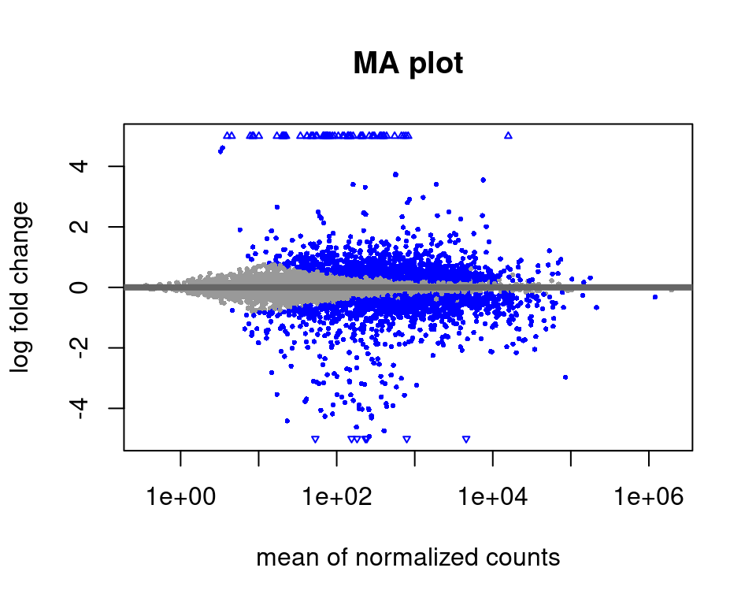

```r
DESeq2::plotMA(res, ylim=c(-5,5), main="MA plot")
```

### Volcano plot

The volcano plot arranges genes along two dimensions: the x-axis is the log fold change between the two groups, and the y-axis represents the adjusted P values between samples (on a negative log scale so smaller p-values appear higher up).

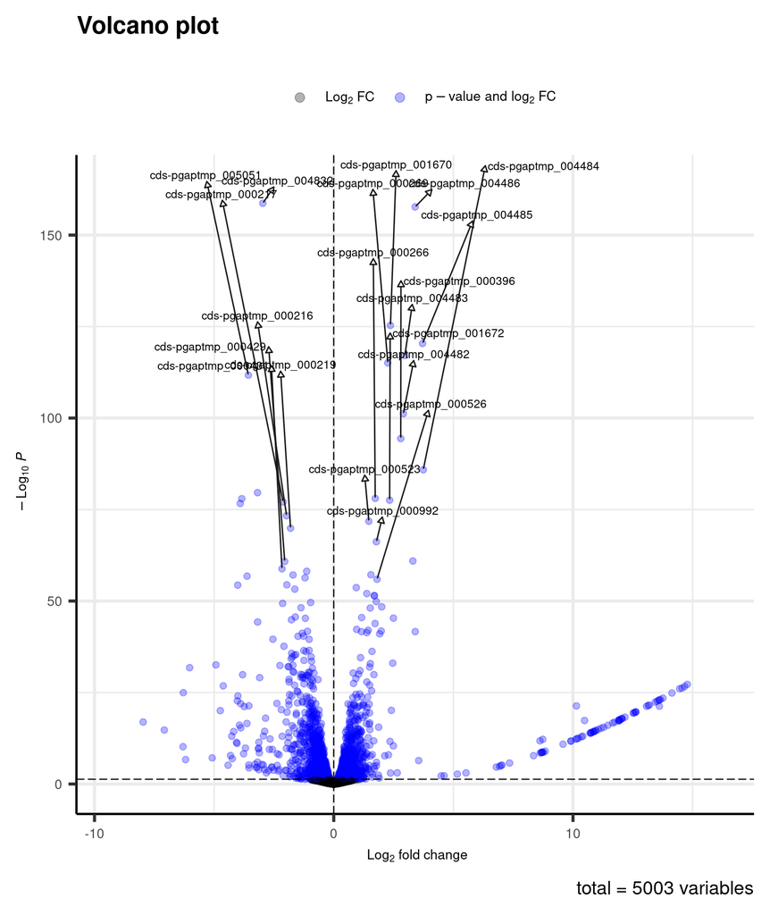

```r
EnhancedVolcano(res, lab = rownames(res), x = 'log2FoldChange', y = 'padj', pCutoff=0.05, FCcutoff=0, subtitleLabSize=0, axisLabSize=10, labSize=3, legendLabSize=10, legendIconSize=3, col=c('black', 'black', 'gold2', 'blue'), colAlpha = 0.3, drawConnectors = TRUE)
```